# Tarea 2

Santiago, Sofía, Román, Luis

24/2/2020

# Ejercicio 2

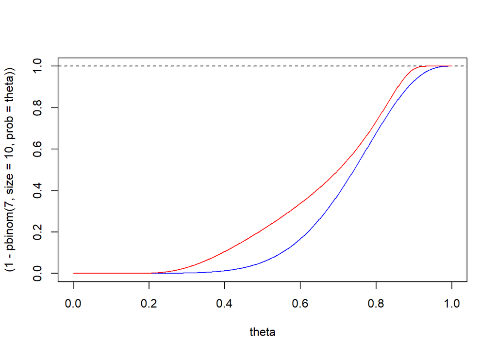

```r
theta <- seq(0, 1, .001)
plot(theta, (1 - pbinom(7, size =  10, prob = theta)), type = "l", col = "blue")
abline(h = 1, col = "black", lty = 2)
lines(theta, (1 - pnorm(7, mean = 10 * theta, sd = 10 * theta * (1- theta))), type = "l", col = "red")
```

# Ejercicio 4

```r
antes <- c(90, 83, 105, 97, 110, 78)
despues <- c(97, 80, 110, 93, 123, 84)
SIGN.test(antes, despues,paired = T, alternative = "less", conf.level = .9)
```

```
##
##  Dependent-samples Sign-Test
##
## data:  antes and despues
## S = 2, p-value = 0.3438
## alternative hypothesis: true median difference is less than 0
## 90 percent confidence interval:
##  -Inf  3.1
## sample estimates:
## median of x-y
##          -5.5
##
## Achieved and Interpolated Confidence Intervals:
##
##                   Conf.Level L.E.pt U.E.pt
## Lower Achieved CI     0.8906   -Inf    3.0
## Interpolated CI       0.9000   -Inf    3.1
## Upper Achieved CI     0.9844   -Inf    4.0
```

```r
wilcox.test(antes, despues, paired = TRUE, exact = TRUE, alternative = "less", conf.level = .9, conf.int = .9)
```

```
##
##  Wilcoxon signed rank test
##
## data:  antes and despues
## V = 3, p-value = 0.07813
## alternative hypothesis: true location shift is less than 0
## 90 percent confidence interval:
##  -Inf -0.5
## sample estimates:
## (pseudo)median
##             -5
```

El valor p de la prueba del signo es .3438 y el intervalo de confianza es de (-inf, 3.1) El valor p de la prueba del rango con signo es .07813 y el intervalo de confianza es de (-inf, -.5). El supuesto que se debe hacer es que la muestra es pareada.

# Ejercicio 5

- Cantidad **mediana** de sueño es de 7,5 hrs, con d.est de 1.5 hrs.
- El 5% de la población duerme 6 o menos.
- El otro 5% duerme 9 o más hrs.
- n = 8.

```r
# data
X <- c(7.2,8.3,5.6,7.4,7.8,5.2,9.1,5.8)
n <- length(data)
# kable(as.array(data),col.names = c("Horas de sueno"))
# quantiles
q_vec <- c(0.05,0.5,0.95)

# empirical quantiles
empq_vec <- c(6,7.5,9)

#alpha
alpha <- 0.05
```

Determinar si los mexicanos duermen menos hoy que lo que hicieron en el pasado. Probarse las hipótesis para los cuantiles 0.05, 0.5 y 0.95.

### Solución:

Como se quiere determinar si los mexicanos duermen **menos** que hoy, se hará una prueba de hipótesis para los cuantíles concernientes con la prueba de hipótesis

$$\mathcal{H}_{0}: \kappa_{p} \le k_{p}^{0}.$$

#### Forma con el valor de K

```r
cat("Pruebas de hipótesis para Kp")
```

```
## Pruebas de hipótesis para Kp
```

```r
for(i in 1:3)
{
  cat(paste("\n\n Para p = ",toString(i), sep = " "))
  # find k
  K <- sum(ifelse(X - empq_vec[i] > 0, 1, 0))
  cat(paste("\nEl valor de K es",toString(K), sep = " "))

  # find s
  fails <- sum( (pbinom(q = 0:n,size = n,prob = 1 - q_vec[i]) < alpha)) #pbinom y de cumulative dist, number of fails
  s <- n - fails
  cat(paste("\nEl valor de s es",toString(s), sep = " "))

  #test Hip
  test <- ifelse(K <= (n - s),'cierta','falsa')
  cat(paste("\n La prueba de hipótesis es",test, sep = " "))
}
```

```
##
##
##  Para p =  1
## El valor de K es 5
## El valor de s es 1
##  La prueba de hipótesis es falsa
##
##  Para p =  2
## El valor de K es 3
## El valor de s es 1
##  La prueba de hipótesis es falsa
##
##  Para p =  3
## El valor de K es 1
## El valor de s es 1
##  La prueba de hipótesis es falsa
```

#### Forma con la estadistica de orden X_{s}

```r
cat("Pruebas de hipótesis para Kp")
```

```
## Pruebas de hipótesis para Kp
```

```r
for(i in 1:3)
{
  cat(paste("\n\n Para p = ",toString(i), sep = " "))
  # find s
  fails <- sum( (pbinom(q = 0:n,size = n,prob = 1 - q_vec[i]) < alpha)) #pbinom y de cumulative dist, number of fails
  s <- n - fails
  cat(paste("\nEl valor de s es",toString(s), sep = " "))

  #find X(s)
  Xs <- X[s+1]  #s can start from cero
  cat(paste("\nEl valor de X(s) es",toString(Xs), sep = " "))
  cat(paste("\nEl valor de kp es",toString(empq_vec[i]), sep = " "))


  #test Hip
  test <- ifelse(Xs <= empq_vec[i],'cierta','falsa')
  cat(paste("\n La prueba de hipótesis es",test, sep = " "))
}
```

```
##
##
##  Para p =  1
## El valor de s es 1
## El valor de X(s) es 8.3
## El valor de kp es 6
##  La prueba de hipótesis es falsa
##
##  Para p =  2
## El valor de s es 1
## El valor de X(s) es 8.3
## El valor de kp es 7.5
##  La prueba de hipótesis es falsa
##
##  Para p =  3
## El valor de s es 1
## El valor de X(s) es 8.3
## El valor de kp es 9
##  La prueba de hipótesis es cierta
```